# Exercício - ANOVA

Author

Published

August 5, 2023

## Pacotes

```r
library(tidyverse) # manipulacao de data.frame
library(broom)
```

## Dados e problema

O dataset `PlantGrowth` contém medidas de tamanhos de uma mesma espécie de planta que foram cultivadas em 3 diferentes condições: ctrl, tr1 e tr2. A condição ctrl corresponde a condição sem intervenção nenhuma. tr1 e tr2 foram condições especiais em que os cientistas estavam interessados em saber se influenciava no crescimento das plantas.

```r
PlantGrowth
```

```
   weight group
1    4.17  ctrl
2    5.58  ctrl
3    5.18  ctrl
4    6.11  ctrl
5    4.50  ctrl
6    4.61  ctrl
7    5.17  ctrl
8    4.53  ctrl
9    5.33  ctrl
10   5.14  ctrl
11   4.81  trt1
12   4.17  trt1
13   4.41  trt1
14   3.59  trt1
```

[output cut: 16 more lines]

## Calcule estatísticas descritivas por grupo

```r
PlantGrowth |>
  dplyr::group_by(group) |>
  dplyr::summarise(
    n = dplyr::n(),
    mean = mean(weight),
    sd = sd(weight)
  )
```

```
# A tibble: 3 × 4
  group     n  mean    sd
  <fct> <int> <dbl> <dbl>
1 ctrl     10  5.03 0.583
2 trt1     10  4.66 0.794
3 trt2     10  5.53 0.443
```

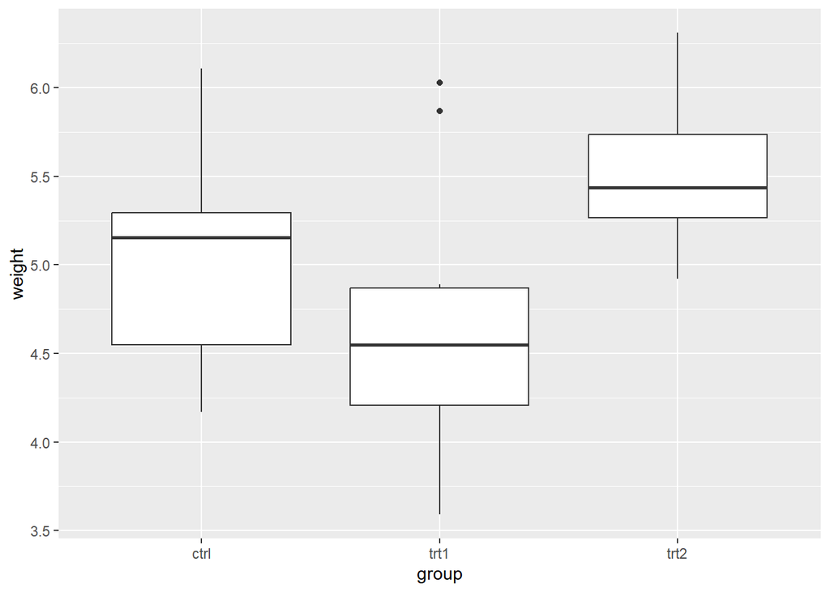

```r
ggplot(PlantGrowth, aes(x = group, y = weight)) +
  geom_boxplot()
```

## Ajuste do modelo

Ajuste um modelo de regressão linear `lm()` para `weigth` explicado por `group`.

```r
modelo <- lm(weight ~ group, data = PlantGrowth)

summary(modelo)
```

```
Call:
lm(formula = weight ~ group, data = PlantGrowth)

Residuals:
    Min      1Q  Median      3Q     Max
-1.0710 -0.4180 -0.0060  0.2627  1.3690

Coefficients:
            Estimate Std. Error t value Pr(>|t|)
(Intercept)   5.0320     0.1971  25.527   <2e-16 ***
grouptrt1    -0.3710     0.2788  -1.331   0.1944
grouptrt2     0.4940     0.2788   1.772   0.0877 .
---
Signif. codes:  0 '***' 0.001 '**' 0.01 '*' 0.05 '.' 0.1 ' ' 1

Residual standard error: 0.6234 on 27 degrees of freedom
Multiple R-squared:  0.2641,    Adjusted R-squared:  0.2096
F-statistic: 4.846 on 2 and 27 DF,  p-value: 0.01591
```

## Diagnóstico

Rode `plot()` do seu modelo. O modelo está bem ajustado? Os resíduos estão em volta do zero? Existem outliers?

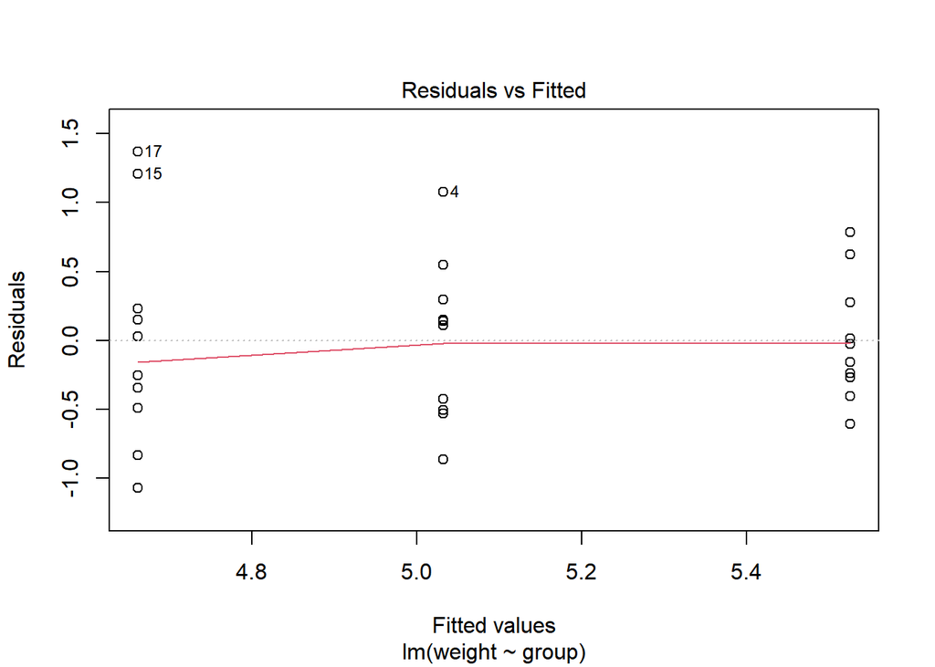

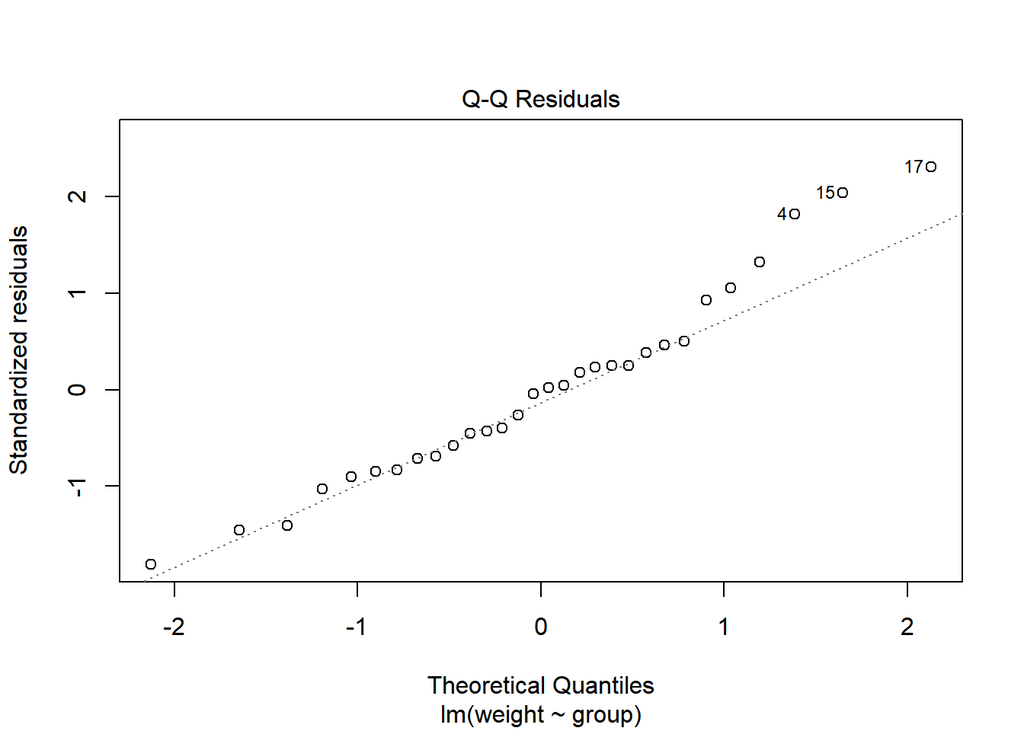

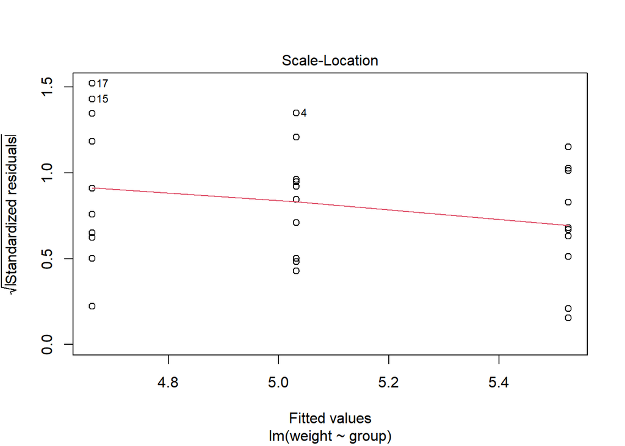

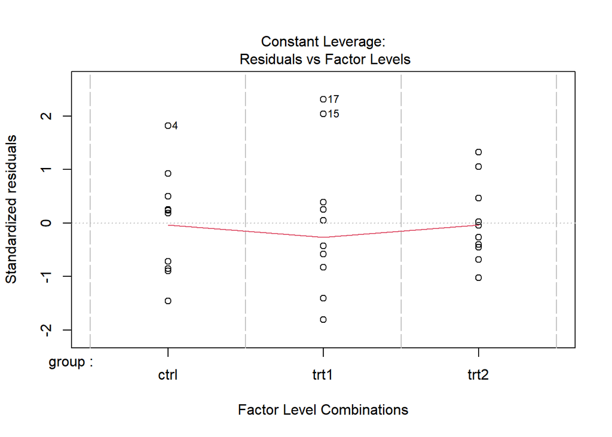

```r
plot(modelo)
```

Pelos gráficos, parece que o modelo está bem ajustado, a menos de um outlier no grupo `ctrl` e dois outliers no grupo `trt1`.

## Inferência

Consulte `summary()`. Quais as conclusões do teste? Compare as conclusões com a inspeção visual (tabela e gráfico acima). Está de acordo?

```r
summary(modelo)
```

```
Call:
lm(formula = weight ~ group, data = PlantGrowth)

Residuals:
    Min      1Q  Median      3Q     Max
-1.0710 -0.4180 -0.0060  0.2627  1.3690

Coefficients:
            Estimate Std. Error t value Pr(>|t|)
(Intercept)   5.0320     0.1971  25.527   <2e-16 ***
grouptrt1    -0.3710     0.2788  -1.331   0.1944
grouptrt2     0.4940     0.2788   1.772   0.0877 .
---
Signif. codes:  0 '***' 0.001 '**' 0.01 '*' 0.05 '.' 0.1 ' ' 1

Residual standard error: 0.6234 on 27 degrees of freedom
Multiple R-squared:  0.2641,    Adjusted R-squared:  0.2096
F-statistic: 4.846 on 2 and 27 DF,  p-value: 0.01591
```

Ambos os testes deram como não significantes a nível de 5%. Isso está de acordo com a inspeção visual, pois os boxplots se sobrepõem.

Faça o mesmo ajuste usando `aov()`

```r
modelo_aov <- aov(weight ~ group, data = PlantGrowth)

summary(modelo_aov)
```

```
            Df Sum Sq Mean Sq F value Pr(>F)
group        2  3.766  1.8832   4.846 0.0159 *
Residuals   27 10.492  0.3886
---
Signif. codes:  0 '***' 0.001 '**' 0.01 '*' 0.05 '.' 0.1 ' ' 1
```

O teste F do `aov` deu como significante a nível de 5%. Isso está de acordo com a inspeção visual, já que os grupos de tratamento deram resultados bem diferentes.

Faça os testes 2 a 2 pelo método de Tukey e Bonferroni

```r
TukeyHSD(modelo_aov)
```

```
  Tukey multiple comparisons of means
    95% family-wise confidence level

Fit: aov(formula = weight ~ group, data = PlantGrowth)

$group
            diff        lwr       upr     p adj
trt1-ctrl -0.371 -1.0622161 0.3202161 0.3908711
trt2-ctrl  0.494 -0.1972161 1.1852161 0.1979960
trt2-trt1  0.865  0.1737839 1.5562161 0.0120064
```

```r
pairwise.t.test(
  PlantGrowth$weight,
  PlantGrowth$group,
  p.adjust.method="bonferroni"
)
```

```
    Pairwise comparisons using t tests with pooled SD

data:  PlantGrowth$weight and PlantGrowth$group

     ctrl  trt1
trt1 0.583 -
trt2 0.263 0.013

P value adjustment method: bonferroni
```

## Conclusão

Os tratamentos tiveram efeito? Quanto?

Ou seja, nenhum dos tratamentos deu significante a nível de 5% quando comparado com o grupo controle. Porém, o tratamento 1 foi significante quando comparado com o tratamento 2. Isso significa que o tratamento 2 aumentou o peso das plantas em relação ao tratamento 1, mas isso não é muito relevante, já que o tratamento 2 não aumentou o peso das plantas em relação ao grupo controle.